# Text Mining using tidy tools

André Nascimento

2022-12-19

# Text Mining using tidy tools

**Sources**:  
https://www.tidytextmining.com/  
https://juliasilge.github.io/tidytext/  
https://github.com/libjohn/workshop_textmining

## Dependencies

```r
# install.packages("janeaustenr")
library(janeaustenr) # provides 6 novels written by Jane Austen
# install.packages("tidyverse")
library(tidyverse) # data manipulation & plotting
# install.packages("tidytext")
library(tidytext) # provides additional text mining functions
# install.packages("wordcloud2")
library(wordcloud2) # world cloud plots
```

## Dataset

We’ll look at some books by Jane Austen, an 18th century novelist. Through the `janeaustenr` package we can access and mine the text of six Austen novels. We can call the collection of novels a corpra. An individual novel is a corpus.

```r
austen_books()
```

|  | text | book |
| --- | --- | --- |
| 1 | SENSE AND SENSIBILITY | Sense & Sensibility |
| 2 |  | Sense & Sensibility |
| 3 | by Jane Austen | Sense & Sensibility |
| 4 |  | Sense & Sensibility |
| 5 | (1811) | Sense & Sensibility |
| 6 |  | Sense & Sensibility |
| 7 |  | Sense & Sensibility |
| 8 |  | Sense & Sensibility |
| 9 |  | Sense & Sensibility |
| 10 | CHAPTER 1 | Sense & Sensibility |

[output cut: 990 more lines]

Austen is best know for six published works:

```r
austen_books() %>%
  distinct(book)
```

| book |
| --- |
| Sense & Sensibility |
| Pride & Prejudice |
| Mansfield Park |
| Emma |
| Northanger Abbey |
| Persuasion |

## Data Cleaning

Text mining typically requires a lot of data cleaning. In this case, we start with the `janeaustenr` collection that has already been cleaned. Nonetheless, further data wrangling is required. First, identifying a line number for each line of text in each book.

### Identify line numbers

```r
original_books <- austen_books() %>%
  group_by(book) %>%
  mutate(line = row_number()) %>%         # identify line numbers
  ungroup()

original_books
```

| text | book | line |
| --- | --- | --- |
| SENSE AND SENSIBILITY | Sense & Sensibility | 1 |
|  | Sense & Sensibility | 2 |
| by Jane Austen | Sense & Sensibility | 3 |
|  | Sense & Sensibility | 4 |
| (1811) | Sense & Sensibility | 5 |
|  | Sense & Sensibility | 6 |
|  | Sense & Sensibility | 7 |
|  | Sense & Sensibility | 8 |
|  | Sense & Sensibility | 9 |
| CHAPTER 1 | Sense & Sensibility | 10 |

[output cut: 990 more lines]

### Tokens

To work with this data as a **tidy** dataset, we need to restructure the data through *tokenization*. In our case a token is a single word. We want **one-token-per-row**. The `unnest_tokens()` function (tidytext package) will convert a data frame with a text column into the one-token-per-row format.

The default tokenizing mode is “words”. With the `unnest_tokens()` function, tokens can be: **words**, characters, character_shingles, **ngrams**, skip_ngrams, **sentences**, lines, paragraphs, regex, tweets, and ptb (Penn Treebank).

```r
tidy_books <- original_books %>%
  unnest_tokens(word, text)

tidy_books
```

| book | line | word |
| --- | --- | --- |
| Sense & Sensibility | 1 | sense |
| Sense & Sensibility | 1 | and |
| Sense & Sensibility | 1 | sensibility |
| Sense & Sensibility | 3 | by |
| Sense & Sensibility | 3 | jane |
| Sense & Sensibility | 3 | austen |
| Sense & Sensibility | 5 | 1811 |
| Sense & Sensibility | 10 | chapter |
| Sense & Sensibility | 10 | 1 |
| Sense & Sensibility | 13 | the |

[output cut: 990 more lines]

And as we can see, some preprocessing was performed was well, as parenthesis and other special characters and punctuation were removed.

> Now that the data is in the one-word-per-row format, we can manipulate it with tidy tools like dplyr.

### Stop Words

**Stop words** are the words in a **stop list** which are filtered out before or after processing of natural language data (text) because they are insignificant.

Now we’ll proceed to remove the stop words from the books.

```r
stop_words <- get_stopwords(language = "en", source = "snowball")
stop_words
```

| word | lexicon |
| --- | --- |
| i | snowball |
| me | snowball |
| my | snowball |
| myself | snowball |
| we | snowball |
| our | snowball |
| ours | snowball |
| ourselves | snowball |
| you | snowball |
| your | snowball |

[output cut: 165 more lines]

```r
matchwords_books <- tidy_books %>%
  anti_join(stop_words)
matchwords_books
```

| book | line | word |
| --- | --- | --- |
| Sense & Sensibility | 1 | sense |
| Sense & Sensibility | 1 | sensibility |
| Sense & Sensibility | 3 | jane |
| Sense & Sensibility | 3 | austen |
| Sense & Sensibility | 5 | 1811 |
| Sense & Sensibility | 10 | chapter |
| Sense & Sensibility | 10 | 1 |
| Sense & Sensibility | 13 | family |
| Sense & Sensibility | 13 | dashwood |
| Sense & Sensibility | 13 | long |

[output cut: 990 more lines]

### Calculate word frequency

How many Austen countable words are there if we remove *snowball* stop-words?

```r
matchwords_books %>%
  count(word, sort = TRUE)
```

| word | n |
| --- | --- |
| mr | 3015 |
| mrs | 2446 |
| must | 2071 |
| said | 2041 |
| much | 1935 |
| miss | 1855 |
| one | 1831 |
| well | 1523 |
| every | 1456 |
| think | 1440 |

[output cut: 990 more lines]

### Word cloud

```r
matchwords_books %>%
  count(word, sort = TRUE) %>%
  head(100) %>%
  wordcloud2(size = .4, shape = 'triangle-forward',
             color = c("steelblue", "firebrick", "darkorchid"),
             backgroundColor = "salmon")
```

[interactive chart not shown]

```r
NA
```

## Sentiment Analysis

### Dictionaries

There are a variety of methods and dictionaries that exist for evaluating the opinion or emotion in text. The tidytext package provides access to several sentiment lexicons. Three general-purpose lexicons are

- `AFINN` from [Finn Årup Nielsen](http://www2.imm.dtu.dk/pubdb/views/publication_details.php?id=6010),
- `bing` from [Bing Liu and collaborators](https://www.cs.uic.edu/~liub/FBS/sentiment-analysis.html), and
- `nrc` from [Saif Mohammad and Peter Turney](http://saifmohammad.com/WebPages/NRC-Emotion-Lexicon.htm).

The `bing` lexicon categorizes words in a binary fashion into positive and negative categories.

The `AFINN` lexicon assigns words with a score that runs between -5 and 5, with negative scores indicating negative sentiment and positive scores indicating positive sentiment.

The `nrc` lexicon categorizes words in a binary fashion (“yes”/“no”) into categories of positive, negative, anger, anticipation, disgust, fear, joy, sadness, surprise, and trust.

```r
head(get_sentiments("bing"))
```

| word | sentiment |
| --- | --- |
| 2-faces | negative |
| abnormal | negative |
| abolish | negative |
| abominable | negative |
| abominably | negative |
| abominate | negative |

```r
head(get_sentiments("afinn"))
```

| word | value |
| --- | --- |
| abandon | -2 |
| abandoned | -2 |
| abandons | -2 |
| abducted | -2 |
| abduction | -2 |
| abductions | -2 |

```r
head(get_sentiments("nrc"))
```

| word | sentiment |
| --- | --- |
| abacus | trust |
| abandon | fear |
| abandon | negative |
| abandon | sadness |
| abandoned | anger |
| abandoned | fear |

```r
get_sentiments("nrc") %>%
  count(sentiment, sort = TRUE)
```

| sentiment | n |
| --- | --- |
| negative | 3316 |
| positive | 2308 |
| fear | 1474 |
| anger | 1245 |
| trust | 1230 |
| sadness | 1187 |
| disgust | 1056 |
| anticipation | 837 |
| joy | 687 |
| surprise | 532 |

### Bing

Let’s see what positive words exist in the bing dictionary. Then, count the frequency of those positive words that exist in *Emma*.

```r
positive <- get_sentiments("bing") %>%
  filter(sentiment == "positive")                    # get POSITIVE words

positive
```

| word | sentiment |
| --- | --- |
| abound | positive |
| abounds | positive |
| abundance | positive |
| abundant | positive |
| accessable | positive |
| accessible | positive |
| acclaim | positive |
| acclaimed | positive |
| acclamation | positive |
| accolade | positive |

[output cut: 990 more lines]

```r
tidy_books %>%
  filter(book == "Emma") %>%                        # only the book _emma_
  semi_join(positive) %>%                           # semi_join()
  count(word, sort = TRUE)
```

| word | n |
| --- | --- |
| well | 401 |
| good | 359 |
| great | 264 |
| like | 200 |
| better | 173 |
| enough | 129 |
| happy | 125 |
| love | 117 |
| pleasure | 115 |
| right | 92 |

[output cut: 658 more lines]

Now let’s do the same but for negative

```r
negative <- get_sentiments("bing") %>%
  filter(sentiment == "negative")                    # get NEGATIVE words

negative
```

| word | sentiment |
| --- | --- |
| 2-faces | negative |
| abnormal | negative |
| abolish | negative |
| abominable | negative |
| abominably | negative |
| abominate | negative |
| abomination | negative |
| abort | negative |
| aborted | negative |
| aborts | negative |

[output cut: 990 more lines]

```r
tidy_books %>%
  filter(book == "Emma") %>%                        # only the book _emma_
  semi_join(negative) %>%                           # semi_join()
  count(word, sort = TRUE)
```

| word | n |
| --- | --- |
| miss | 599 |
| poor | 136 |
| doubt | 98 |
| afraid | 65 |
| sorry | 61 |
| bad | 60 |
| cold | 54 |
| impossible | 41 |
| object | 39 |
| wrong | 39 |

[output cut: 866 more lines]

#### Prepare to visualize sentiment score

Match all the Austen books to the bing sentiment dictionary. Count the word frequency.

```r
tidy_books %>%
  inner_join(get_sentiments("bing")) %>%
  count(book)
```

| book | n |
| --- | --- |
| Sense & Sensibility | 8604 |
| Pride & Prejudice | 8704 |
| Mansfield Park | 11577 |
| Emma | 11966 |
| Northanger Abbey | 5762 |
| Persuasion | 5674 |

#### Calculate sentiment

> **Algorithm:** sentiment = positive - negative

Define a section of text.

> “Small sections of text may not have enough words in them to get a good estimate of sentiment while really large sections can wash out narrative structure. For these books, using 80 lines works well, but this can vary depending on individual texts… – [Text Mining with R](https://www.tidytextmining.com/sentiment.html)

```r
bing <- get_sentiments("bing")

janeaustensentiment <- tidy_books %>%
  inner_join(bing) %>%
  count(book, index = line %/% 80, sentiment) %>%                          # `%/%` = int division ; 80 lines / section
  pivot_wider(names_from = sentiment, values_from = n, values_fill = 0) %>%    # spread(sentiment, n, fill = 0)
  mutate(sentiment = positive - negative)                                      # ALGO!!!
janeaustensentiment
```

| book | index | negative | positive | sentiment |
| --- | --- | --- | --- | --- |
| Sense & Sensibility | 0 | 16 | 32 | 16 |
| Sense & Sensibility | 1 | 19 | 53 | 34 |
| Sense & Sensibility | 2 | 12 | 31 | 19 |
| Sense & Sensibility | 3 | 15 | 31 | 16 |
| Sense & Sensibility | 4 | 16 | 34 | 18 |
| Sense & Sensibility | 5 | 16 | 51 | 35 |
| Sense & Sensibility | 6 | 24 | 40 | 16 |
| Sense & Sensibility | 7 | 23 | 51 | 28 |
| Sense & Sensibility | 8 | 30 | 40 | 10 |
| Sense & Sensibility | 9 | 15 | 19 | 4 |

[output cut: 910 more lines]

**Visualizing**

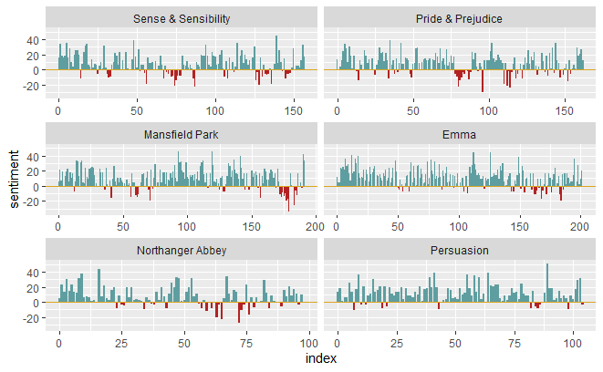

```r
janeaustensentiment %>%
  ggplot(aes(index, sentiment, )) +
  geom_col(show.legend = FALSE, fill = "cadetblue") +
  geom_col(data = . %>% filter(sentiment < 0), show.legend = FALSE, fill = "firebrick") +
  geom_hline(yintercept = 0, color = "goldenrod") +
  facet_wrap(~ book, ncol = 2, scales = "free_x")
```

#### Preparation: Most common positive and negative words

```r
bing_word_counts <- tidy_books %>%
  inner_join(bing) %>%
  count(word, sentiment, sort = TRUE)
bing_word_counts
```

| word | sentiment | n |
| --- | --- | --- |
| miss | negative | 1855 |
| well | positive | 1523 |
| good | positive | 1380 |
| great | positive | 981 |
| like | positive | 725 |
| better | positive | 639 |
| enough | positive | 613 |
| happy | positive | 534 |
| love | positive | 495 |
| pleasure | positive | 462 |

[output cut: 990 more lines]

**Visualize it too**

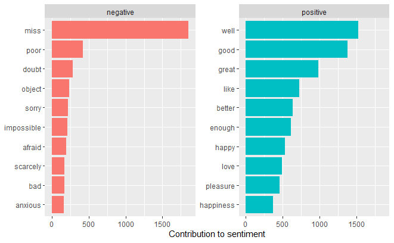

```r
bing_word_counts %>%
  group_by(sentiment) %>%
  slice_max(n, n = 10) %>%
  ungroup() %>%
  mutate(word = reorder(word, n)) %>%
  ggplot(aes(n, word, fill = sentiment)) +
  geom_col(show.legend = FALSE) +
  facet_wrap(~sentiment, scales = "free_y") +
  labs(x = "Contribution to sentiment",
       y = NULL)
```

### Comparing the 3 sentiment dictionaries

Let’s use all three sentiment lexicons and examine how the sentiment changes across the narrative arc of *Pride and Prejudice*.

```r
pride_prejudice <- tidy_books %>%
  filter(book == "Pride & Prejudice")

pride_prejudice
```

| book | line | word |
| --- | --- | --- |
| Pride & Prejudice | 1 | pride |
| Pride & Prejudice | 1 | and |
| Pride & Prejudice | 1 | prejudice |
| Pride & Prejudice | 3 | by |
| Pride & Prejudice | 3 | jane |
| Pride & Prejudice | 3 | austen |
| Pride & Prejudice | 7 | chapter |
| Pride & Prejudice | 7 | 1 |
| Pride & Prejudice | 10 | it |
| Pride & Prejudice | 10 | is |

[output cut: 990 more lines]

Let’s again calculate the sentiment using the previous algorithm: use integer division (`%/%`) to define larger sections of text that span multiple lines, and we can use the same pattern with [`count()`](https://dplyr.tidyverse.org/reference/count.html), [`pivot_wider()`](https://tidyr.tidyverse.org/reference/pivot_wider.html), and [`mutate()`](https://dplyr.tidyverse.org/reference/mutate.html) to find the net sentiment in each of these sections of text.

```r
afinn <- pride_prejudice %>%
  inner_join(get_sentiments("afinn")) %>%
  group_by(index = line %/% 80) %>%
  summarise(sentiment = sum(value)) %>%
  mutate(method = "AFINN")
bing_and_nrc <- bind_rows(
  pride_prejudice %>%
    inner_join(get_sentiments("bing")) %>%
    mutate(method = "Bing et al."),
  pride_prejudice %>%
    inner_join(get_sentiments("nrc") %>%
                 filter(sentiment %in% c("positive",
                                         "negative"))
    ) %>%
    mutate(method = "NRC")) %>%
  count(method, index = line %/% 80, sentiment) %>%
  pivot_wider(names_from = sentiment,
              values_from = n,
              values_fill = 0) %>%
  mutate(sentiment = positive - negative)
```

We now have an estimate of the net sentiment (positive - negative) in each chunk of the novel text for each sentiment lexicon. Let’s bind them together and **visualize them:**

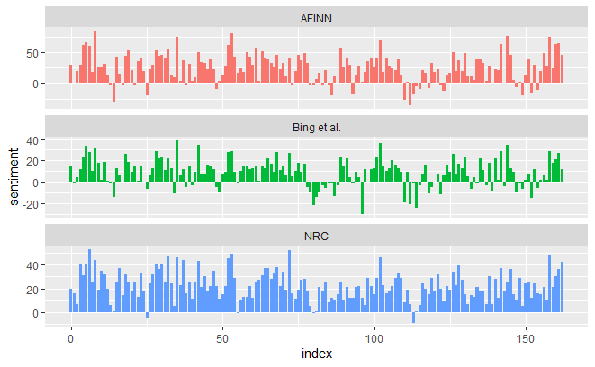

```r
bind_rows(afinn, bing_and_nrc) %>%
  ggplot(aes(index, sentiment, fill = method)) +
  geom_col(show.legend = FALSE) +
  facet_wrap(~method, ncol = 1, scales = "free_y")
```

Check why NRC is so positive biased:

```r
get_sentiments("nrc") %>%
  filter(sentiment %in% c("positive", "negative")) %>%
  count(sentiment)
```

| sentiment | n |
| --- | --- |
| negative | 3316 |
| positive | 2308 |

```r
get_sentiments("bing") %>%
  count(sentiment)
```

| sentiment | n |
| --- | --- |
| negative | 4781 |
| positive | 2005 |

Both lexicons have more negative than positive words, but the ratio of negative to positive words is higher in the Bing lexicon than the NRC lexicon!